# ANLY 520 Final Project - Sentiment Analysis of US Airline Industry Customers Tweets

Oluwatobi Akinyemi & Pavan Chavda

2020-04-17

## Introduction

For companies, there is a lot of information on social media, both relevant and irrelevant, that they can utilize to determine the sentiments of people towards their brand. However, the challenge is to develop a system that can accurately analyze large amount of information and predict the sentiment.

For airline industry in particular, social media can be a great way to listen to direct consumer feedback and monitor their brand image. They are one of the largest industries in the world that serves millions of people all over the globe. The United States has the largest air travel market of any single country, with nearly 850 million people using air travel in 2017 [Statistics & Facts: Passenger airlines in the U.S.].

One of the most efficient way to determine sentiments and monitor brand image on twitter is perform sentiment analysis using machine learning models that can predict the sentiments based on the text. sis a great tool for extracting useful information from social media. Sentiment analysis ia a contextual mining of text which identifies and extracts useful information from text data. It is the most common text classification tool that analyzes text data and tells whether the underlying sentiment is positive, negative or neutral. This technique can be very useful for businesses to understand the social sentiment of their brand, product or service.

## Hypothesis/Research Question

The goal of this research project is to apply the sentimnt analysis technique on tweets to airlines in the US. The study will explore the following research question.

- Can the sentiment of tweets be accurately predicted using sentiment analysis technique?

## Data

The dataset was taken from Crowdflower website. The data consists of all tweets by twitter users in February 2015 for 6 major airlines in the US: American, Delta, Southwest, United, US Airways, and Virgin America. There are roughly 14.5k tweets and includes 15 different variables. Each tweet has a sentiment labeled to it and there are three possible sentiments: positive, neutral and negative. For negative sentiments, the data also includes reasons such as bad flight, customer service, late flight, etc.

## Methodology

The methodology for this research project consists of the following steps:

- Data Analysis
- Data Pre-processing
- Data modeling
- Performance Analysis
- Model comparison

## Statistical Analysis

We will first load all the libraries and functions that will be used in the research project. We will also load our dataset here.

### Loading libraries

```r
##r chunk
library("reticulate")
```

```python
##python chunk
import pandas as pd
import numpy as np
import nltk
import textblob
from bs4 import BeautifulSoup
import unicodedata
import contractions
#if you want to stem
from nltk import PorterStemmer
ps = PorterStemmer()
from model_evaluation_utils import display_model_performance_metrics
```

### Loading Data

- This dataset includes tweets that have been coded as either negative, positive or neutral.

```python
##python chunk
dataset = pd.read_csv('tweets.csv')
dataset.shape
```

```
## (14640, 15)
```

```python
dataset.head()
```

```
##              tweet_id  ...               user_timezone
## 0  570306133677760513  ...  Eastern Time (US & Canada)
## 1  570301130888122368  ...  Pacific Time (US & Canada)
## 2  570301083672813571  ...  Central Time (US & Canada)
## 3  570301031407624196  ...  Pacific Time (US & Canada)
## 4  570300817074462722  ...  Pacific Time (US & Canada)
##
## [5 rows x 15 columns]
```

```python
print(dataset.info())
```

```
## <class 'pandas.core.frame.DataFrame'>
## RangeIndex: 14640 entries, 0 to 14639
## Data columns (total 15 columns):
## tweet_id                        14640 non-null int64
## airline_sentiment               14640 non-null object
## airline_sentiment_confidence    14640 non-null float64
## negativereason                  9178 non-null object
## negativereason_confidence       10522 non-null float64
## airline                         14640 non-null object
## airline_sentiment_gold          40 non-null object
## name                            14640 non-null object
## negativereason_gold             32 non-null object
## retweet_count                   14640 non-null int64
## text                            14640 non-null object
## tweet_coord                     1019 non-null object
## tweet_created                   14640 non-null object
## tweet_location                  9907 non-null object
## user_timezone                   9820 non-null object
## dtypes: float64(2), int64(2), object(11)
## memory usage: 1.7+ MB
## None
```

```python
#select desired columns
dataset = dataset[['airline','airline_sentiment','text']]
dataset.head()
```

```
##           airline  ...                                               text
## 0  Virgin America  ...                @VirginAmerica What @dhepburn said.
## 1  Virgin America  ...  @VirginAmerica plus you've added commercials t...
## 2  Virgin America  ...  @VirginAmerica I didn't today... Must mean I n...
## 3  Virgin America  ...  @VirginAmerica it's really aggressive to blast...
## 4  Virgin America  ...  @VirginAmerica and it's a really big bad thing...
##
## [5 rows x 3 columns]
```

### Data Pre-processing

We will first clean our data using our clean_text function. The clean_text function definted below performs following steps on our text data:

- Remove HTML code
- Lowest case
- Remove contractions
- Replace all non-compatible characters with their equivalents

The clean_text function does not correct spelling as people tend to use lot of abbreviations while posting anything online and so that it doesnt consider words such as names.

```python
##python chunk
STOPWORDS = set(nltk.corpus.stopwords.words('english')) #stopwords
STOPWORDS.remove('no')
STOPWORDS.remove('but')
STOPWORDS.remove('not')

def clean_text(text):
    text = BeautifulSoup(text).get_text() #html
    text = text.lower() #lower case
    text = contractions.fix(text) #contractions
    text = unicodedata.normalize('NFKD', text).encode('ascii', 'ignore').decode('utf-8', 'ignore') #symbols
    #text = ' '.join([ps.stem(word) for word in text.split()]) #stem
    text = ' '.join(word for word in text.split() if word not in STOPWORDS) # stopwords
    return text

dataset['text'] = dataset['text'].apply(clean_text)
dataset.head()
```

```
##           airline  ...                                               text
## 0  Virgin America  ...                     @virginamerica @dhepburn said.
## 1  Virgin America  ...  @virginamerica plus added commercials experien...
## 2  Virgin America  ...  @virginamerica not today... must mean need tak...
## 3  Virgin America  ...  @virginamerica really aggressive blast obnoxio...
## 4  Virgin America  ...                @virginamerica really big bad thing
##
## [5 rows x 3 columns]
```

### Data Modeling

Now, let’s start developing our models. We will first start the modeling using Textblob method.

#### TextBlob

- Before running the model, we will first split our dataset into train and test data with 80/20 train/test ratio. We will calculate the polarity for all the tweets in our dataset.
- We will use the cut off score of 0 and change the polarity numbers to positive and negative categories.
- We will then convert our dataset to categorical labels to see the accuracy of our model.

```python
##python chunk
tweets = np.array(dataset['text'])
sentiments = np.array(dataset['airline_sentiment'])

from sklearn.model_selection import train_test_split

train_tweets, test_tweets, train_sentiments, test_sentiments = train_test_split(tweets, sentiments, test_size=0.20, random_state = 42)
train_tweets.shape
```

```
## (11712,)
```

```python
test_tweets.shape

#calculate sentiment for smaller example set
```

```
## (2928,)
```

```python
sentiment_polarity = [textblob.TextBlob(tweet).sentiment.polarity for tweet in test_tweets]

#convert to categorical labels
predicted_sentiments = ['positive' if score > 0 else 'neutral' if score == 0 else 'negative' for score in sentiment_polarity]

#display performance metrics
display_model_performance_metrics(true_labels=test_sentiments, predicted_labels=predicted_sentiments,
                                  classes=['positive', 'negative', 'neutral'])
```

```
## Model Performance metrics:
## ------------------------------
## Accuracy: 0.4556
## Precision: 0.6864
## Recall: 0.4556
## F1 Score: 0.4698
##
## Model Classification report:
## ------------------------------
##               precision    recall  f1-score   support
##
##     positive       0.34      0.78      0.47       459
##     negative       0.89      0.34      0.50      1889
##      neutral       0.28      0.56      0.38       580
##
##     accuracy                           0.46      2928
##    macro avg       0.51      0.56      0.45      2928
## weighted avg       0.69      0.46      0.47      2928
##
##
## Prediction Confusion Matrix:
## ------------------------------
##                  Predicted:
##                    positive negative neutral
## Actual: positive        357       17      85
##         negative        502      651     736
##         neutral         194       60     326
```

#### AFINN

```python
##python chunk
from afinn import Afinn

#load the model
afn = Afinn(emoticons=True)

#predict the polarity
sentiment_polarity = [afn.score(tweet) for tweet in test_tweets]

#convert to categorical labels
predicted_sentiments = ['positive' if score > 0 else 'neutral' if score == 0 else 'negative' for score in sentiment_polarity]

#display performance metrics
display_model_performance_metrics(true_labels=test_sentiments, predicted_labels=predicted_sentiments,
                                  classes=['positive', 'negative', 'neutral'])
```

```
## Model Performance metrics:
## ------------------------------
## Accuracy: 0.5007
## Precision: 0.6892
## Recall: 0.5007
## F1 Score: 0.5259
##
## Model Classification report:
## ------------------------------
##               precision    recall  f1-score   support
##
##     positive       0.30      0.86      0.45       459
##     negative       0.89      0.45      0.60      1889
##      neutral       0.33      0.39      0.36       580
##
##     accuracy                           0.50      2928
##    macro avg       0.51      0.57      0.47      2928
## weighted avg       0.69      0.50      0.53      2928
##
##
## Prediction Confusion Matrix:
## ------------------------------
##                  Predicted:
##                    positive negative neutral
## Actual: positive        395       17      47
##         negative        639      845     405
##         neutral         269       85     226
```

Now, we will train our own model to create a better classifier.

#### TF-IDF

We will first create a testing and training dataset using the TF-IDF vectorizer and build TF-IDF features on training dataset.

```python
##python chunk
from sklearn.feature_extraction.text import TfidfVectorizer
train_tweets, test_tweets, train_sentiments, test_sentiments = train_test_split(tweets, sentiments, test_size=0.20, random_state = 42)
train_tweets.shape
```

```
## (11712,)
```

```python
test_tweets.shape

# build TFIDF features on train tweets
```

```
## (2928,)
```

```python
tv = TfidfVectorizer(use_idf=True, min_df=0.0, max_df=1.0, ngram_range=(1,2),
                     sublinear_tf=True)
tv_train_features = tv.fit_transform(train_tweets)
tv_test_features = tv.transform(test_tweets)
```

#### Logistic Regression Classifier

Now, to train the model, we will first try logistic regression classifier. We will create a blank logistic regression model, fit the model to the training data and predict the sentiment on the testing data.

```python
##python chunk
from sklearn.linear_model import LogisticRegression

#blank model
lr = LogisticRegression(penalty='l2', max_iter=1000, C=1)

# fit the model
lr_tfidf_model = lr.fit(tv_train_features, train_sentiments)

# grab the predictions
lr_tfidf_predictions = lr_tfidf_model.predict(tv_test_features)
```

##### Accuracy and Classification Report

```python
##python chunk
#model performance
display_model_performance_metrics(true_labels=test_sentiments,
  predicted_labels=lr_tfidf_predictions,
  classes=['positive', 'negative', 'neutral'])
```

```
## Model Performance metrics:
## ------------------------------
## Accuracy: 0.8016
## Precision: 0.7931
## Recall: 0.8016
## F1 Score: 0.7887
##
## Model Classification report:
## ------------------------------
##               precision    recall  f1-score   support
##
##     positive       0.81      0.63      0.71       459
##     negative       0.82      0.94      0.88      1889
##      neutral       0.69      0.47      0.56       580
##
##     accuracy                           0.80      2928
##    macro avg       0.77      0.68      0.72      2928
## weighted avg       0.79      0.80      0.79      2928
##
##
## Prediction Confusion Matrix:
## ------------------------------
##                  Predicted:
##                    positive negative neutral
## Actual: positive        289      123      47
##         negative         29     1784      76
##         neutral          38      268     274
```

#### Decision Tree Classifier

For the next model, we will try Decision Tree Classifier and check if it works better than other models we have built.

```python
##python chunk
from sklearn.tree import DecisionTreeClassifier

#blank model
dtree = DecisionTreeClassifier()

# fit the model
dtree_model = dtree.fit(tv_train_features, train_sentiments)

# grab the predictions
dtree_predictions = dtree_model.predict(tv_test_features)
```

##### Accuracy and Classification Report

```python
##python chunk
#model performance
display_model_performance_metrics(true_labels=test_sentiments,
  predicted_labels=dtree_predictions,
  classes=['positive', 'negative', 'neutral'])
```

```
## Model Performance metrics:
## ------------------------------
## Accuracy: 0.6503
## Precision: 0.6964
## Recall: 0.6503
## F1 Score: 0.6665
##
## Model Classification report:
## ------------------------------
##               precision    recall  f1-score   support
##
##     positive       0.52      0.56      0.54       459
##     negative       0.84      0.71      0.77      1889
##      neutral       0.37      0.53      0.44       580
##
##     accuracy                           0.65      2928
##    macro avg       0.58      0.60      0.58      2928
## weighted avg       0.70      0.65      0.67      2928
##
##
## Prediction Confusion Matrix:
## ------------------------------
##                  Predicted:
##                    positive negative neutral
## Actual: positive        259       82     118
##         negative        142     1337     410
##         neutral         101      171     308
```

#### Random Forest

For the last model, we will build a model using Random Forest method.

```python
##python chunk
from sklearn.ensemble import RandomForestClassifier

#blank model
rf = RandomForestClassifier(n_estimators=200)

# fit the model
rf_model = rf.fit(tv_train_features, train_sentiments)

# grab the predictions
rf_predictions =rf_model.predict(tv_test_features)
```

##### Accuracy and Classification Report

```python
##python chunk
#model performance
display_model_performance_metrics(true_labels=test_sentiments,
  predicted_labels=rf_predictions,
  classes=['positive', 'negative', 'neutral'])
```

```
## Model Performance metrics:
## ------------------------------
## Accuracy: 0.7821
## Precision: 0.7734
## Recall: 0.7821
## F1 Score: 0.7732
##
## Model Classification report:
## ------------------------------
##               precision    recall  f1-score   support
##
##     positive       0.77      0.58      0.66       459
##     negative       0.82      0.91      0.87      1889
##      neutral       0.60      0.51      0.55       580
##
##     accuracy                           0.78      2928
##    macro avg       0.73      0.67      0.69      2928
## weighted avg       0.77      0.78      0.77      2928
##
##
## Prediction Confusion Matrix:
## ------------------------------
##                  Predicted:
##                    positive negative neutral
## Actual: positive        265      121      73
##         negative         40     1728     121
##         neutral          37      246     297
```

#### Topic Model

- Create a dataset of just the positive reviews.
- Create a dictionary and document term matrix to start the topics model.

```python
##python chunk
#load packages
import pyLDAvis
```

```python
import pyLDAvis.gensim  # don't skip this
import matplotlib.pyplot as plt
import gensim
import gensim.corpora as corpora

#create separate datasets of positive and negative tweets
positive = dataset[dataset['airline_sentiment']=="positive"]
positive_tweets = positive['text'].apply(nltk.word_tokenize)

negative = dataset[dataset['airline_sentiment']=="negative"]
negative_tweets = negative['text'].apply(nltk.word_tokenize)

#create a dictionary of the words
dictionary_positive = corpora.Dictionary(positive_tweets)
dictionary_negative = corpora.Dictionary(negative_tweets)

#create a doc term matrix
pos_doc_term_matrix = [dictionary_positive.doc2bow(doc) for doc in positive_tweets]
neg_doc_term_matrix = [dictionary_negative.doc2bow(doc) for doc in negative_tweets]
```

##### LDA Topic Model Design

- Create the LDA Topic Model for the positive reviews with three topics.

```python
##python chunk
#create LDA topic model for +ve dictionary
lda_model_pos = gensim.models.ldamodel.LdaModel(
  corpus = pos_doc_term_matrix, #TDM
  id2word = dictionary_positive, #Dictionary
  num_topics = 3,
  random_state = 100,
  update_every = 1,
  chunksize = 100,
  passes = 10,
  alpha = 'auto',
  per_word_topics = True)
```

```python
##python chunk
#create LDA topic model for -ve dictionary
lda_model_neg = gensim.models.ldamodel.LdaModel(
  corpus = neg_doc_term_matrix, #TDM
  id2word = dictionary_negative, #Dictionary
  num_topics = 3,
  random_state = 100,
  update_every = 1,
  chunksize = 100,
  passes = 10,
  alpha = 'auto',
  per_word_topics = True)
```

##### Terms for the Topics

- Top terms for each of the positive topics.

```python
##python chunk
#Top terms in +ve dictionary
print(lda_model_pos.print_topics())
```

```
## [(0, '0.135*"." + 0.075*"americanair" + 0.048*"thanks" + 0.041*"," + 0.028*"usairways" + 0.028*"@" + 0.014*"not" + 0.010*"I" + 0.008*"?" + 0.008*"good"'), (1, '0.138*"@" + 0.117*"!" + 0.034*"#" + 0.031*"jetblue" + 0.029*"thank" + 0.025*":" + 0.019*"flight" + 0.017*"you" + 0.014*"great" + 0.013*")…
```

- Top terms for each of the negative topics

```python
##python chunk
#Top terms in -ve dictionary
print(lda_model_neg.print_topics())
```

```
## [(0, '0.214*"americanair" + 0.049*"#" + 0.014*"customer" + 0.012*"plane" + 0.011*"service" + 0.011*"would" + 0.011*"``" + 0.010*"gate" + 0.010*"\'\'" + 0.009*"agent"'), (1, '0.091*"@" + 0.085*"." + 0.033*"not" + 0.029*"?" + 0.028*"," + 0.026*"flight" + 0.023*"!" + 0.013*"no" + 0.012*"get" + 0.012…
```

###### Interactive Graphics

```python
##python chunk
vis = pyLDAvis.gensim.prepare(lda_model_pos, pos_doc_term_matrix, dictionary_positive, n_jobs = 1)
pyLDAvis.save_html(vis, 'LDA_Visualization_Positive.html')

vis = pyLDAvis.gensim.prepare(lda_model_neg, neg_doc_term_matrix, dictionary_negative, n_jobs = 1)
pyLDAvis.save_html(vis, 'LDA_Visualization_Negative.html')
```

- Positive Topics Visualization

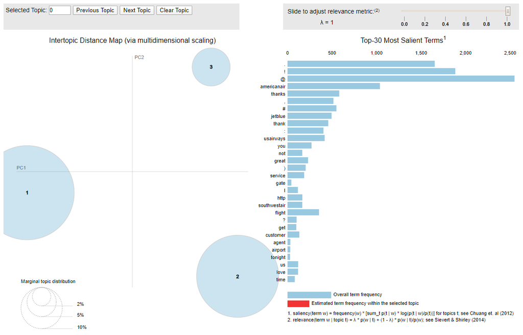

The above visualization reveals that Topic 0 contains 52% of the tokens in the dataset. It includes words like the airline names, “thanks”, “not”, and “good”. Further exploration of the topics through the topic visualization above reveals more terms like “great”, “customer”, “service” and “flight” suggesting that this topic is most likely related to great customer service.

A similar examination of the above terms and visualization shows that Topic 1 contains 39.6% of the tokens, it and includes words like “thank”, “flight”, “you” and “great” suggesting that this topic may also be related to customer experience in relation to flights. Further analysis may be required to clearly delineate these topics.

Topic 2 contains only 8.5% of the tokens, and it includes a mix of positive and neutral words like “gate”, “agent”, “airport”, “tonight”, “nice”, “warm” and “seat”, and traditionally negative words like “cancelled” and “problems” suggesting that this topic may be related to customer experience during problem resolution conversations with agents and other airlines staff.

- Negative Topics Visualization

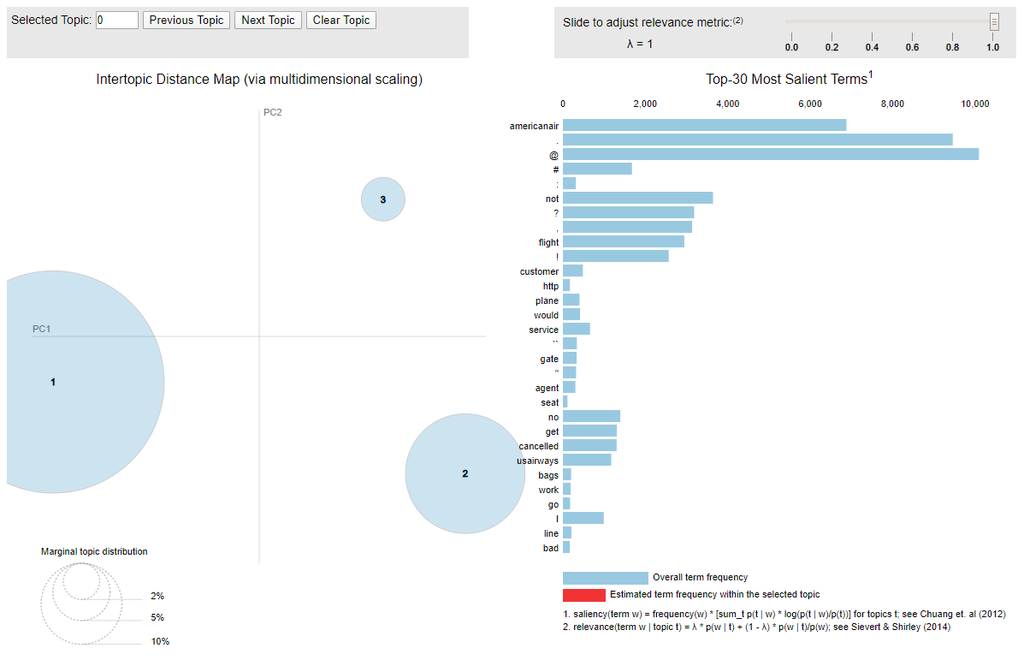

Topic 0 contains 75.3% of the tokens, and it includes words like “customer”, “plane”, “service”, “gate” and “agent” suggesting that this topic may be related to customer service.

Topic 1 is made up of 21.8% of the tokens, and it includes words like “not”, “flight”, “no”, “get” and “cancelled” suggesting that this topic may be related to cancelled flights.

Finally, Topic 2, which consists a mere 2.9% of the tokens, includes words like “seat”, “broken”, “legroom”, “club” and “sell” suggesting that this topic may be related to seating comfort.

## Results

In this section, we will discuss the results of our sentiment analysis. Our objective was to investigate the possibility of designing a machine learning algorithm capable of predicting sentiments from airline customers’ tweets with a decent measure of precision and accurately. For the classification task, we compared the performance of five modeling methods:

- TextBlob
- AFINN lexicon method
- Logistic Regression Classifier
- Decision Tree Classifier
- Random Forest Classifier

In preparation for the last three classification methods, we Used the TF-IDF supervised learning approach to extract features, which we trained the models on before running predictions.

[output not shown]

## Conclusion

Social media channels have become one of the primary ways brands use to engage their customers. Platforms like microblogging site Twitter provide great utility for this purpose as they can be used as a direct lines of contact for customers to reach a company’s customer service desk to seek redress of issues, information and other help. Many customers also use this medium to vend their opinions on brands and products. These opinions or reviews may be either customers’ compliments or their frustrations. For this reason, the unstructured data available on Twitter is a gold mine of customer feedback, which can be mined using natural language processing methods like sentiment analysis to measure these opinions and determine ways to improve brand or product performance.

The aim of this project was to design an algorithm capable of processing the tweets of US airline customers, and classifying them according to sentiment with precision. Of the five different algorithms tested, results showed that extracting features with the TF-IDF supervised learning approach, and fitting a model with a Logistic Regression algorithm would yield the best performing classification model by accuracy, precision, recall and f1 score.

## References

Crowdflower: https://www.crowdflower.com/data-for-everyone/

Wikipedia: https://en.wikipedia.org/wiki/Social_media

The rise of social media: https://ourworldindata.org/rise-of-social-media

Passenger airlines in the U.S. - Statistics & Facts: https://www.statista.com/topics/5575/passenger-airlines-in-the-us/

statista: https://www.statista.com/statistics/282087/number-of-monthly-active-twitter-users/

Joshi, S. (n.d.). Aspect based sentiment analysis for United States of America Airlines MSc Research Project Data Analytics.

Prabhakar, E., Santhosh, M., Krishnan, A. H., Kumar, T., & Sudhakar B B Student, R. (n.d.). Sentiment Analysis of US Airline Twitter Data using New Adaboost Approach. www.ijert.org

van de Kruis, S. (n.d.). Sentiment analysis on tweets Measuring the correctness of sentiment analysis on brand attitude.